# Research Publications Affiliated with Luxembourg: A Data-Driven Analysis

## 1 Introduction

This report presents a comprehensive analysis of Luxembourg’s research publication landscape using data extracted from OpenAlex, an open-access scholarly metadata platform. OpenAlex serves as a freely accessible alternative to proprietary academic databases, providing structured information about publications, authors, institutional affiliations, and research collaborations across all academic disciplines.

The data collection methodology focuses on identifying all scholarly works with Luxembourg institutional affiliations recorded in OpenAlex over the past decade. This approach captures both research led by Luxembourg-based scholars and international collaborative projects where Luxembourg institutions participate as co-authors. The temporal scope provides a current snapshot of the country’s scientific output and evolving research partnerships.

OpenAlex aggregates metadata from multiple sources including institutional repositories, publisher databases, and citation networks. While this multi-source approach enhances coverage comprehensiveness, data quality depends on the accuracy of source reporting and the platform’s ability to correctly identify and link Luxembourg-affiliated works. These methodological considerations should be kept in mind when interpreting the analytical findings presented throughout this report.

## 2 Data Structure and Document Types

The initial dataset encompasses all document types recorded in OpenAlex for Luxembourg-affiliated scholarly works during the study period. The following table displays the distribution of work types and the presence of Digital Object Identifiers (DOIs), which serve as persistent identifiers linking to original publications:

Table 1: Distribution of types of work and missingness of DOI

|  | Type | DOI_missing | Has_DOI | Total |
| --- | --- | --- | --- | --- |
| 1 | article | 24320 | 9755 | 34075 |
| 2 | book | 267 | 89 | 356 |
| 3 | book-chapter | 2982 | 54 | 3036 |
| 4 | dataset | 878 | 0 | 878 |
| 5 | dissertation | 35 | 52 | 87 |
| 6 | editorial | 190 | 1 | 191 |
| 7 | erratum | 102 | 0 | 102 |
| 8 | letter | 232 | 1 | 233 |
| 9 | other | 92 | 80 | 172 |
| 10 | paratext | 145 | 8 | 153 |

[output cut: 5 more lines]

Based on the substantial predominance of journal articles in the dataset and their central importance in academic research communication, this analysis restricts its focus to articles exclusively. This selection encompasses both publications with DOI identifiers and those without, ensuring comprehensive coverage of Luxembourg’s peer-reviewed research output.

The analytical framework employs a critical distinction based on first authorship status: whether the primary author maintains affiliation with a Luxembourg institution or represents an international collaboration where Luxembourg institutions participate as secondary contributors. This classification enables differentiation between research leadership and research participation within the national research ecosystem:

Table 2: Number of articles where the first author is LU-affiliated

Select Year Range:

|  | Publication Year | Non-LU first author | LU first author |
| --- | --- | --- | --- |
| 1 | 2015 | 806 | 987 |
| 2 | 2016 | 800 | 1051 |
| 3 | 2017 | 925 | 1156 |
| 4 | 2018 | 953 | 1210 |
| 5 | 2019 | 1000 | 1227 |
| 6 | 2020 | 1087 | 1269 |
| 7 | 2021 | 1269 | 1423 |
| 8 | 2022 | 1371 | 1475 |
| 9 | 2023 | 1366 | 1556 |
| 10 | 2024 | 1229 | 1333 |

[output cut: 1 more lines]

## 3 Research Domain Analysis

The following visualization examines the temporal distribution of Luxembourg-affiliated research across major scientific domains. The data utilizes OpenAlex’s domain classification system, which categorizes research fields into broad disciplinary areas. The analysis tracks publication volumes over time while maintaining the distinction between Luxembourg-led research (first author affiliation) and collaborative research (non-first author participation):

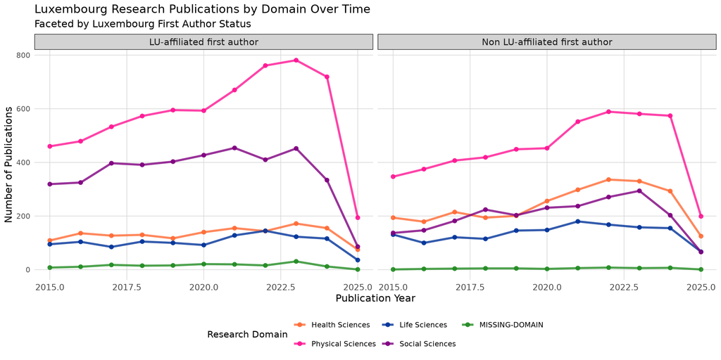

Observable js version of the graph:

[interactive chart not shown]

## 4 International Collaboration Patterns

The analysis extends to examining Luxembourg’s research collaboration patterns with international partners. The dataset contains information about co-author affiliations, enabling identification of the most frequent collaborating countries and regions. This section presents the geographical distribution of research partnerships, organized by publication year and distinguished by Luxembourg’s role as lead author versus collaborative partner.

The data processing groups countries into meaningful categories, including major individual nations, regional blocs, and an aggregated “Others” category for countries with lower collaboration frequencies. This approach provides clarity while maintaining analytical depth regarding Luxembourg’s primary research partnerships:

[figure not shown]